# Lab 2: Quantitative Variables

Solution

## The Dataset

This analysis is an exploration of a dataset containing the results of all Cal Poly’s basketball games in the 2015-2016 season. The data has been loaded and named `bball`.

```r
bball %>% head()
```

```
## # A tibble: 6 x 7
##   Date  Team  Team.Location Team.Score Opponent Opponent.Score Team.Result
##   <fct> <fct> <fct>              <int> <fct>             <int> <fct>
## 1 11/1~ Cal ~ Away                  72 Nevada-~             74 Loss
## 2 11/1~ Cal ~ Away                  83 UCLA                 88 Loss
## 3 12/3~ Cal ~ Home                  73 IPFW                 75 Loss
## 4 12/5~ Cal ~ Home                  77 Fresno ~             65 Win
## 5 12/1~ Cal ~ Away                  63 Saint M~             93 Loss
## 6 12/1~ Cal ~ Away                  82 Souther~            101 Loss
```

```r
bball %>% summary
```

```
##       Date          Team    Team.Location   Team.Score
##  1/14/16: 1   Cal Poly:27   Away:15       Min.   :50.00
##  1/16/16: 1                 Home:12       1st Qu.:65.50
##  1/21/16: 1                               Median :73.00
##  1/23/16: 1                               Mean   :72.44
##  1/28/16: 1                               3rd Qu.:79.50
##  1/30/16: 1                               Max.   :96.00
##  (Other):21
##                  Opponent  Opponent.Score   Team.Result
##  Cal State Fullerton : 2   Min.   : 53.00   Loss:19
##  Cal State Northridge: 2   1st Qu.: 72.00   Win : 8
##  Hawaii              : 2   Median : 75.00
##  Long Beach State    : 2   Mean   : 75.63
##  UC-Davis            : 2   3rd Qu.: 79.00
##  UC-Irvine           : 2   Max.   :101.00
##  (Other)             :15
```

## Is Cal Poly a worse than average team?

An “average” team is defined to be a team that is just as likely to lose as to win a game. We would like to determine if Cal Poly’s team was average or not. Fill in the blanks in the discussion below. Use the code chunk below to run any code you need for calculations.

```r
pbinom(19, 27, 0.5)
```

```
## [1] 0.9904214
```

```r
8/27
```

```
## [1] 0.2962963
```

If Cal Poly was truly an average team, the probability that they win any given game is `50%`.

Assume Cal Poly is an average team. Define the random variable X = “number of games Cal Poly wins in a season”. The distribution of X is `Binomial(27, 0.5)`. The mean of X is `13.5`.

The probability that X is less than or equal to 19 is 0.9904214.

In the 2015-16 Season, Cal Poly won `8` games and lost `19` games. This means they won 29.6296296% of their games.

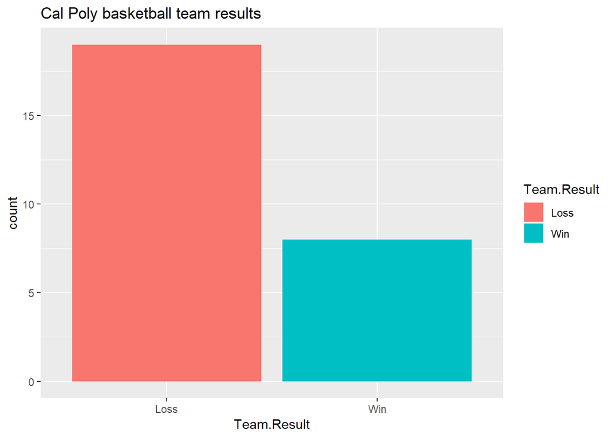

```r
ggplot(bball, aes(x = Team.Result, fill = Team.Result)) + geom_bar() + ggtitle("Cal Poly basketball team results")
```

## Was Cal Poly more likely to win at home than away?

Perhaps Cal Poly performs better in front of a home crowd. Let’s find out.

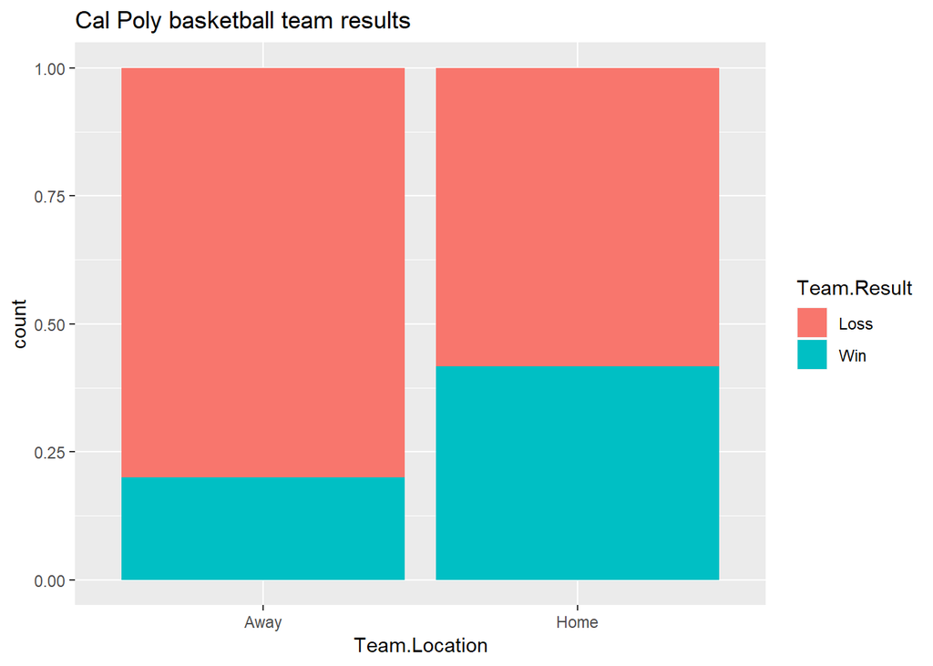

```r
ggplot(bball, aes(x = Team.Location, fill = Team.Result)) + geom_bar(position = "fill") + ggtitle("Cal Poly basketball team results")
```

```r
bball %>% count(Team.Location, Team.Result)
```

```
## # A tibble: 4 x 3
##   Team.Location Team.Result     n
##   <fct>         <fct>       <int>
## 1 Away          Loss           12
## 2 Away          Win             3
## 3 Home          Loss            7
## 4 Home          Win             5
```

Cal Poly seems to be much more likely to win at home than away.

## Does Cal Poly score more at home than away?

Perhaps Cal Poly scores more in front of a home crowd, regardless of wins and losses.

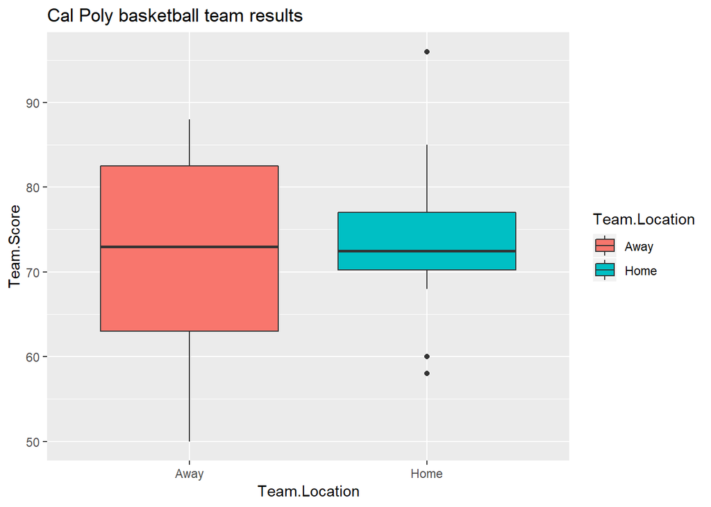

```r
ggplot(bball, aes(x = Team.Location, fill = Team.Location, y = Team.Score)) + geom_boxplot() + ggtitle("Cal Poly basketball team results")
```

```r
bball %>% group_by(Team.Location) %>% summarize_at(vars(Team.Score), funs(mean, sd))
```

```
## # A tibble: 2 x 3
##   Team.Location  mean    sd
##   <fct>         <dbl> <dbl>
## 1 Away           71.7  11.8
## 2 Home           73.4  10.1
```

In Home Games, Cal Poly scored an average of `73.4` points, with a standard deviation of `10.1` points. In Away Games, Cal Poly scored an average of `71.7` points, with a standard deviation of `11.8` points.

There does not seem to be much difference in the number of points Cal Poly scores at home versus away.

## Does Cal Poly truly play better at home?

Consider the following argument:

“Even if Cal Poly didn’t score much more at home than away, they still played better. This is because they played better defense at home, so the scores overall were lower.”

Make an argument in favor or against this statement. Include *more than one* summary statistic in your analysis, and make at least one plot.

For 5 points EC, include a correctly used *probability statement* in your analysis, to quantify your evidence.